# Enfermedades de coral

31 de agosto de 2018

## Las enfermedades

A lo largo de la historia de los seres vivos siempre han existido enfermedades que han impactado los ciclos de vida de los organismos, a mediados del siglo XX su incidencia se ha ido incrementando, llegando a reportarse a partir de 1970, 616 nuevos brotes de enfermedades al año, afectando de igual manera en ambientes marinos y terrestres.

En las colonias de coral es difícil determinar una enfermedad, debido a que se desconoce el agente causal, por lo que solo se registran los signos que ocurren al mismo tiempo y que frecuentemente apuntan a un síndrome o a una enfermedad.

Entre los principales signos están:

- Ys = Signo Amarillo
- Ws = Signo Blanco
- Ds = Puntos oscuros
- BE, BP, BS = Signos de Blanqueamiento
- BB = Banda Negra

Para evaluar el efecto que tienen sobre las colonias se calcula la superfie total de las colonias y se le resta el área que ha muerto por diversas causas. La superficie promedio de las colonias fue de 12, indicando que las colonias contaban con más de 300 años de antigüedad, lamentablemente el promedio de tejido vivo que aún conservaban era de 4.

## Modelos que se evaluaron

```r
mod1<-lm(AreFrag.m2 ~ frag,data=CM)
mod2<-lm(AreFrag.m2 ~ frag+Signo,data=CM)
mod3<-lm(AreFrag.m2 ~ frag+Signo+Signo2+algas,data=CM)
mod4<-lm(AreFrag.m2 ~ frag:Signo,data=CM)
mod5<-lm(AreFrag.m2 ~ frag*Signo*Signo2*algas,data=CM)
```

Donde:

- AreFrag.2 = Área de total de tejido vivo de la colonia
- frag = No. de fragmentos en los que se dividió la colonia
- Signo = Diferentes signos encontrados en cada colonia
- algas = presencia de cualquier tipo de algas

## Modelos

Tabla comparativa con las características principales de los modelos

| r.squared | df | AIC | Modelo | DeltaAIC |
| --- | --- | --- | --- | --- |
| 0.6250892 | 2 | 281.9344 | mod1 | 0.000000 |
| 0.6560011 | 6 | 285.2016 | mod4 | 3.267272 |
| 0.6392434 | 6 | 287.8177 | mod2 | 5.883344 |
| 0.6829152 | 14 | 296.7208 | mod3 | 14.786457 |
| 0.7720056 | 27 | 304.5792 | mod5 | 22.644813 |

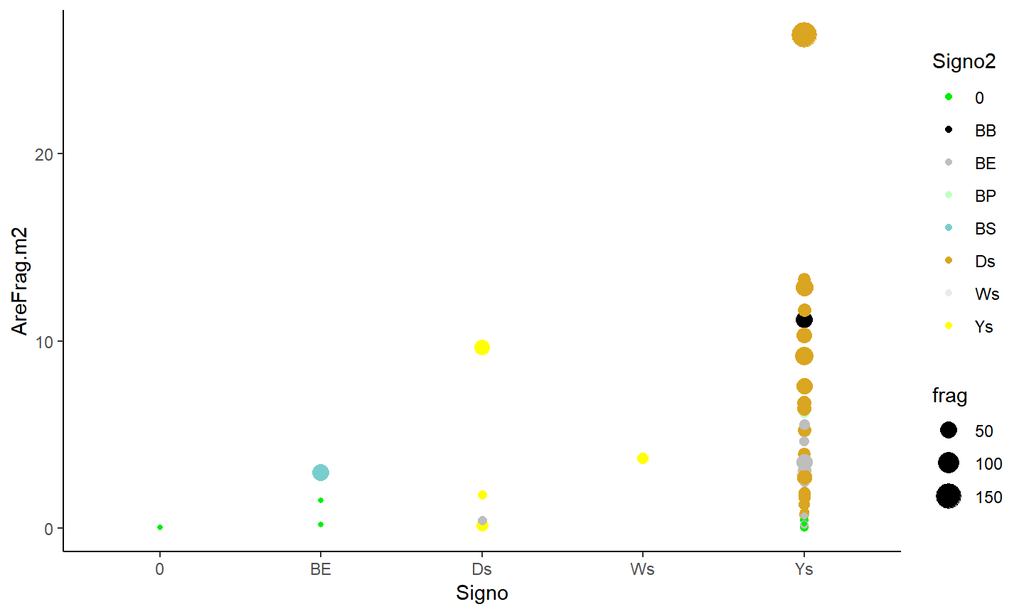

Fig. 1 Principales signos encontrados en el área de tejido vivo de las colonias doralinas, el tamaño de los círculos representa la proporción de fragmentos provocados por la presencia de los signos